# Laboratorio 2

Carlos Montiel - 15000552v

En este laboratorio deber predecir las ventas para los próximos 12 meses de las tiendas Favorita. El dataset tiene la información a nivel de familias de productos. El dataset cuenta con fechas, información de productos y tiendas, si el articulo estaba en alguna promoción y a la cantidad de ventas. También hay datasets adicionales que complementan información y le pueden ser de utilidad para sus modelos.

## Entrega

- Debe predecir las ventas para los próximos 12 meses.
- Debe predecir las ventas diarias.
- Debe realizar al menos 3 modelos diferentes
- Debe **comentar** su código para **identificar cada uno de los modelos**.
- Deber entregar un notebook. De preferencia el html. Si tiene inconvenientes puede entregar el archivo laboratorio_2.Rmd. **NO entregar archivos xxx.r**
- Su modelo debe ser a nivel general y no a nivel de tienda o producto. Es decir que puede agregar los datos a nivel de fecha.

### Train.csv

- Los datos de entrenamiento, que comprenden series de tiempo de los atributos store_nbr, family y onpromotion, así como las ventas objetivo.
- store_nbr la tienda en donde se vendieron los productos
- family identifica el tipo de producto
- sales es la cantidad de ventas de un producto en cierta fecha en cierta tienda. Pueden haber números decimales porque hay productos que no se venden en cantidades enteras. Por ejemplo, 1.5kg de queso a diferencia de 1 bolsa de frituras.

### Stores.csv

- Metadata de las tiendas como ciudad, estado, tipo y cluster
- Cluster es una agrupación de tiendas similares

### Holidays_events.csv

- Metadata sobre asuetos y festividades da considerar
- Nota: Poner atención a la columna transferred . Esta columna indica cuando una festividad se corre de fecha. Por ejemplo la independencia de Guayaquil era el 2012-10-09 pero se celebró el 2012-10-12.
- También se identifican festividades adicionales a las de ley

### Notas

- Los salarios en el sector publico se pagan el 15 de cada mes y el último día de cada mes. Esto puede afectar los comportamientos
- Un terremoto de magnitud 7.8 golpeó Ecuador el 2016-04-16. Esto afecto los comportamientos de venta en los supermercados.

```r
install.packages('prophet')
```

```r
library(tidyverse)
```

```r
library(dplyr)
```

```r
library(prophet)
```

Utilizando prophet de la libreria de facebook vamos a predecir utilizando una regresión lineal

```r
data_t <- read.csv('train.csv', colClasses = c(NA,"Date",NA,NA,NA,NA))
glimpse(data_t)
```

```
Rows: 3,000,888
Columns: 6
$ id          <int> 0, 1, 2, 3, 4, 5, 6, 7, 8, 9, 10, 11, 12, 13, 14, 15, 16, ~
$ date        <date> 2013-01-01, 2013-01-01, 2013-01-01, 2013-01-01, 2013-01-0~
$ store_nbr   <int> 1, 1, 1, 1, 1, 1, 1, 1, 1, 1, 1, 1, 1, 1, 1, 1, 1, 1, 1, 1~
$ family      <chr> "AUTOMOTIVE", "BABY CARE", "BEAUTY", "BEVERAGES", "BOOKS",~
$ sales       <dbl> 0, 0, 0, 0, 0, 0, 0, 0, 0, 0, 0, 0, 0, 0, 0, 0, 0, 0, 0, 0~
$ onpromotion <dbl> 0, 0, 0, 0, 0, 0, 0, 0, 0, 0, 0, 0, 0, 0, 0, 0, 0, 0, 0, 0~
```

```r
data_t
```

| id | date | store_nbr | family | sales | onpromotion |
| --- | --- | --- | --- | --- | --- |
| 563 | 2013-01-01 | 25 | BEAUTY | 2.000 | 0 |
| 564 | 2013-01-01 | 25 | BEVERAGES | 810.000 | 0 |
| 566 | 2013-01-01 | 25 | BREAD/BAKERY | 180.589 | 0 |
| 568 | 2013-01-01 | 25 | CLEANING | 186.000 | 0 |
| 569 | 2013-01-01 | 25 | DAIRY | 143.000 | 0 |
| 570 | 2013-01-01 | 25 | DELI | 71.090 | 0 |
| 571 | 2013-01-01 | 25 | EGGS | 46.000 | 0 |
| 572 | 2013-01-01 | 25 | FROZEN FOODS | 29.655 | 0 |
| 573 | 2013-01-01 | 25 | GROCERY I | 700.000 | 0 |
| 574 | 2013-01-01 | 25 | GROCERY II | 15.000 | 0 |

[output cut: 990 more lines]

```r
summary(data_t)
```

```
       id               date              store_nbr       family
 Min.   :      0   Min.   :2013-01-01   Min.   : 1.0   Length:3000888
 1st Qu.: 750222   1st Qu.:2014-02-26   1st Qu.:14.0   Class :character
 Median :1500444   Median :2015-04-24   Median :27.5   Mode  :character
 Mean   :1500444   Mean   :2015-04-24   Mean   :27.5
 3rd Qu.:2250665   3rd Qu.:2016-06-19   3rd Qu.:41.0
 Max.   :3000887   Max.   :2017-08-15   Max.   :54.0
     sales           onpromotion
 Min.   :     0.0   Min.   :   0.0
 1st Qu.:     0.0   1st Qu.:   0.0
 Median :    11.0   Median :   1.0
 Mean   :   357.8   Mean   :  34.6
 3rd Qu.:   195.8   3rd Qu.:  16.0
 Max.   :124717.0   Max.   :1006.0
```

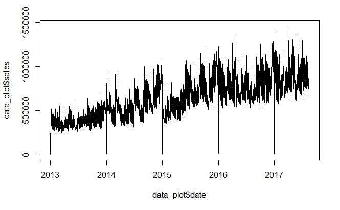

```r
data_plot <- data_t %>% group_by(date) %>% summarise(sales = sum(sales))
plot(data_plot$date, data_plot$sales, type = 'l')
```

```r
data_stores <- read.csv('stores.csv')
glimpse(data_stores)
```

```
Rows: 54
Columns: 5
$ store_nbr <int> 1, 2, 3, 4, 5, 6, 7, 8, 9, 10, 11, 12, 13, 14, 15, 16, 17, 1~
$ city      <chr> "Quito", "Quito", "Quito", "Quito", "Santo Domingo", "Quito"~
$ state     <chr> "Pichincha", "Pichincha", "Pichincha", "Pichincha", "Santo D~
$ type      <chr> "D", "D", "D", "D", "D", "D", "D", "D", "B", "C", "B", "C", ~
$ cluster   <int> 13, 13, 8, 9, 4, 13, 8, 8, 6, 15, 6, 15, 15, 7, 15, 3, 12, 1~
```

```r
summary(data_stores)
```

```
   store_nbr         city              state               type
 Min.   : 1.00   Length:54          Length:54          Length:54
 1st Qu.:14.25   Class :character   Class :character   Class :character
 Median :27.50   Mode  :character   Mode  :character   Mode  :character
 Mean   :27.50
 3rd Qu.:40.75
 Max.   :54.00
    cluster
 Min.   : 1.000
 1st Qu.: 4.000
 Median : 8.500
 Mean   : 8.481
 3rd Qu.:13.000
 Max.   :17.000
```

```r
data_holidays <- read.csv('holidays_events.csv')
glimpse(data_holidays)
```

```
Rows: 350
Columns: 6
$ date        <chr> "2012-03-02", "2012-04-01", "2012-04-12", "2012-04-14", "2~
$ type        <chr> "Holiday", "Holiday", "Holiday", "Holiday", "Holiday", "Ho~
$ locale      <chr> "Local", "Regional", "Local", "Local", "Local", "Local", "~
$ locale_name <chr> "Manta", "Cotopaxi", "Cuenca", "Libertad", "Riobamba", "Pu~
$ description <chr> "Fundacion de Manta", "Provincializacion de Cotopaxi", "Fu~
$ transferred <chr> "False", "False", "False", "False", "False", "False", "Fal~
```

```r
summary(data_holidays)
```

```
     date               type              locale          locale_name
 Length:350         Length:350         Length:350         Length:350
 Class :character   Class :character   Class :character   Class :character
 Mode  :character   Mode  :character   Mode  :character   Mode  :character
 description        transferred
 Length:350         Length:350
 Class :character   Class :character
 Mode  :character   Mode  :character
```

## Prediccion de ventas usando Prophet

```r
data_t <- data_t %>%
  filter(sales != 0)
```

Necesitamos ds, y para poder utilizar prophet

```r
names(data_t)[2] <- 'ds'
names(data_t)[5] <- 'y'
```

```r
tail(data_t)
```

|  | id | ds | store_nbr | family | y | onpromotion |
| --- | --- | --- | --- | --- | --- | --- |
| 2061753 | 3000882 | 2017-08-15 | 9 | PLAYERS AND ELECTRONICS | 6.000 | 2 |
| 2061754 | 3000883 | 2017-08-15 | 9 | POULTRY | 438.133 | 15 |
| 2061755 | 3000884 | 2017-08-15 | 9 | PREPARED FOODS | 154.553 | 8 |
| 2061756 | 3000885 | 2017-08-15 | 9 | PRODUCE | 2419.729 | 148 |
| 2061757 | 3000886 | 2017-08-15 | 9 | SCHOOL AND OFFICE SUPPLIES | 121.000 | 10 |
| 2061758 | 3000887 | 2017-08-15 | 9 | SEAFOOD | 16.000 | 2 |

Realizamos la prediccion para 365 dias siguientes

```r
m <- prophet(data_t)
```

```
Disabling daily seasonality. Run prophet with daily.seasonality=TRUE to override this.
```

Hacemos los 365 dias

```r
future <- make_future_dataframe(m, periods = 365)
```

```r
forecast<- predict(m, future)
tail(forecast[c('ds', 'yhat', 'yhat_lower', 'yhat_upper')])
```

|  | ds | yhat | yhat_lower | yhat_upper |
| --- | --- | --- | --- | --- |
| 2044 | 2018-08-10 | 511.3911 | -1091.7587 | 2191.302 |
| 2045 | 2018-08-11 | 650.5502 | -900.3986 | 2222.078 |
| 2046 | 2018-08-12 | 716.1453 | -1020.7826 | 2425.062 |
| 2047 | 2018-08-13 | 536.2606 | -973.7093 | 2165.381 |
| 2048 | 2018-08-14 | 501.1558 | -1101.4980 | 2229.960 |
| 2049 | 2018-08-15 | 522.0428 | -1174.1011 | 2316.671 |

```r
forecast %>%
  filter(ds > '2017-08-15') %>%
  select(ds, yhat)
```

| ds | yhat |
| --- | --- |
| 2017-08-16 | 507.1201 |
| 2017-08-17 | 438.1048 |
| 2017-08-18 | 500.9610 |
| 2017-08-19 | 642.2801 |
| 2017-08-20 | 709.9517 |
| 2017-08-21 | 532.0100 |
| 2017-08-22 | 498.6675 |
| 2017-08-23 | 521.0928 |
| 2017-08-24 | 453.0265 |
| 2017-08-25 | 516.5634 |

[output cut: 355 more lines]

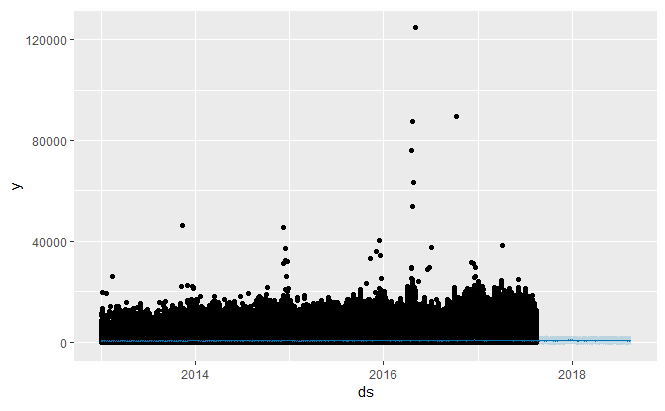

```r
plot(m, forecast)
```

```r
prophet_plot_components(m, forecast)
```

[output not shown]

```r
x <- data_t$ds
y <- data_t$y
datos<-data.frame(Dia=x, Ventas=y)
datos
```

| Dia | Ventas |
| --- | --- |
| 2013-01-01 | 2.000 |
| 2013-01-01 | 810.000 |
| 2013-01-01 | 180.589 |
| 2013-01-01 | 186.000 |
| 2013-01-01 | 143.000 |
| 2013-01-01 | 71.090 |
| 2013-01-01 | 46.000 |
| 2013-01-01 | 29.655 |
| 2013-01-01 | 700.000 |
| 2013-01-01 | 15.000 |

[output cut: 990 more lines]

Append de 30 dias

```r
days <- 30
for(z in c(1:days)){
    datos <- datos %>%
      add_row(Ventas = NA)
}
```

```r
tail(datos)
```

|  | Dia | Ventas |
| --- | --- | --- |
| 2061783 |  | NA |
| 2061784 |  | NA |
| 2061785 |  | NA |
| 2061786 |  | NA |
| 2061787 |  | NA |
| 2061788 |  | NA |

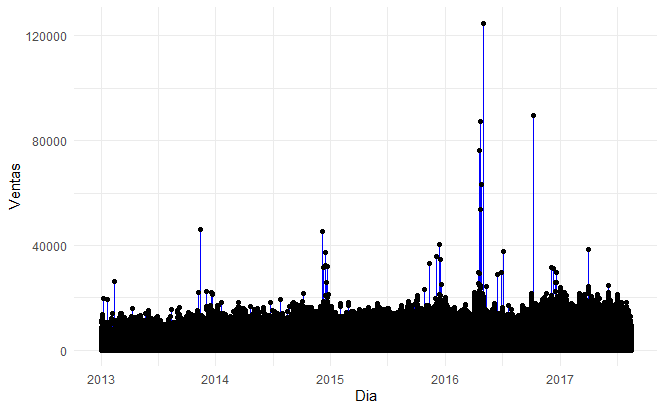

```r
datos %>%
  ggplot(aes(x=Dia, y=Ventas))+
  geom_line(col="blue")+
  geom_point(aes(x=Dia, y=Ventas))+
  theme_minimal()
```

```r
tail(datos)
```

[output not shown]

Obtenemos tendencia MM

```r
datos<-data.frame(datos, Tendencia=MM)
datos
```

[output not shown]

[output cut: 990 more lines]

```r
tail(datos)
```

|  | Dia | Ventas | CE | Tendencia |
| --- | --- | --- | --- | --- |
| 2061783 |  | NA | NA | NA |
| 2061784 |  | NA | NA | NA |
| 2061785 |  | NA | NA | NA |
| 2061786 |  | NA | NA | NA |
| 2061787 |  | NA | NA | NA |
| 2061788 |  | NA | NA | NA |

Obtenemos la variancia

```r
varY<-c()
for(i in c(1:k)){
  varX<-seq(i, length(arr), by=k)
  varY<-c(varY, mean(datos[varX, 4], na.rm= TRUE))
}
length(varY)
```

```
[1] 4
```

```r
varY <- rep(varY, 515447)
length(varY)
```

```
[1] 2061788
```

```r
datos <- data.frame(datos, St=varY)
datos
```

| Dia | Ventas | CE | Tendencia | St |
| --- | --- | --- | --- | --- |
| 2013-01-01 | 2.000 | NA | NA | 415.6524 |
| 2013-01-01 | 810.000 | NA | NA | 416.4171 |
| 2013-01-01 | 180.589 | 0.778021353 | 232.113167 | 416.6970 |
| 2013-01-01 | 186.000 | 0.776791475 | 239.446500 | 415.9431 |
| 2013-01-01 | 143.000 | 1.307261244 | 109.389000 | 415.6524 |
| 2013-01-01 | 71.090 | 0.362782747 | 195.957500 | 416.4171 |
| 2013-01-01 | 46.000 | 0.274696565 | 167.457500 | 416.6970 |
| 2013-01-01 | 29.655 | 0.205998291 | 143.957500 | 415.9431 |
| 2013-01-01 | 700.000 | 5.265434311 | 132.942500 | 415.6524 |
| 2013-01-01 | 15.000 | 0.105059797 | 142.775833 | 416.4171 |

[output cut: 990 more lines]

```r
tail(datos)
```

|  | Dia | Ventas | CE | Tendencia | St |
| --- | --- | --- | --- | --- | --- |
| 2061783 |  | NA | NA | NA | 416.6970 |
| 2061784 |  | NA | NA | NA | 415.9431 |
| 2061785 |  | NA | NA | NA | 415.6524 |
| 2061786 |  | NA | NA | NA | 416.4171 |
| 2061787 |  | NA | NA | NA | 416.6970 |
| 2061788 |  | NA | NA | NA | 415.9431 |

```r
datos<-data.frame(datos, Irr=(datos[, 2]/datos[,5]))
datos
```

| Dia | Ventas | CE | Tendencia | St | Irr |
| --- | --- | --- | --- | --- | --- |
| 2013-01-01 | 2.000 | NA | NA | 415.6524 | 0.004811713 |
| 2013-01-01 | 810.000 | NA | NA | 416.4171 | 1.945165178 |
| 2013-01-01 | 180.589 | 0.778021353 | 232.113167 | 416.6970 | 0.433382022 |
| 2013-01-01 | 186.000 | 0.776791475 | 239.446500 | 415.9431 | 0.447176518 |
| 2013-01-01 | 143.000 | 1.307261244 | 109.389000 | 415.6524 | 0.344037476 |
| 2013-01-01 | 71.090 | 0.362782747 | 195.957500 | 416.4171 | 0.170718262 |
| 2013-01-01 | 46.000 | 0.274696565 | 167.457500 | 416.6970 | 0.110391956 |
| 2013-01-01 | 29.655 | 0.205998291 | 143.957500 | 415.9431 | 0.071295802 |
| 2013-01-01 | 700.000 | 5.265434311 | 132.942500 | 415.6524 | 1.684099533 |
| 2013-01-01 | 15.000 | 0.105059797 | 142.775833 | 416.4171 | 0.036021577 |

[output cut: 990 more lines]

```r
tail(datos)
```

|  | Dia | Ventas | CE | Tendencia | St | Irr |
| --- | --- | --- | --- | --- | --- | --- |
| 2061783 |  | NA | NA | NA | 416.6970 | NA |
| 2061784 |  | NA | NA | NA | 415.9431 | NA |
| 2061785 |  | NA | NA | NA | 415.6524 | NA |
| 2061786 |  | NA | NA | NA | 416.4171 | NA |
| 2061787 |  | NA | NA | NA | 416.6970 | NA |
| 2061788 |  | NA | NA | NA | 415.9431 | NA |

```r
modelo<-lm(formula = Irr ~ Dia, data=datos)
summary(modelo)
```

```
Call:
lm(formula = Irr ~ Dia, data = datos)

Residuals:
    Min      1Q  Median      3Q     Max
 -1.402  -1.226  -1.037  -0.306 298.191

Coefficients:
              Estimate Std. Error t value Pr(>|t|)
(Intercept) -2.149e+00  7.615e-02  -28.23   <2e-16 ***
Dia          2.044e-04  4.574e-06   44.67   <2e-16 ***
---
Signif. codes:  0 ‘***’ 0.001 ‘**’ 0.01 ‘*’ 0.05 ‘.’ 0.1 ‘ ’ 1

Residual standard error: 3.115 on 2061756 degrees of freedom
  (30 observations deleted due to missingness)
Multiple R-squared:  0.0009671, Adjusted R-squared:  0.0009666
F-statistic:  1996 on 1 and 2061756 DF,  p-value: < 2.2e-16
```

```r
preds <- predict(object = modelo, newdata = datos)
```

```r
datos<-data.frame(datos, Ftrend=preds)
datos
```

|  | Dia | Ventas | CE | Tendencia | St | Irr | Ftrend |
| --- | --- | --- | --- | --- | --- | --- | --- |
| 1 | 2013-01-01 | 2.000 | NA | NA | 415.6524 | 0.004811713 | 1.060111 |
| 2 | 2013-01-01 | 810.000 | NA | NA | 416.4171 | 1.945165178 | 1.060111 |
| 3 | 2013-01-01 | 180.589 | 0.778021353 | 232.113167 | 416.6970 | 0.433382022 | 1.060111 |
| 4 | 2013-01-01 | 186.000 | 0.776791475 | 239.446500 | 415.9431 | 0.447176518 | 1.060111 |
| 5 | 2013-01-01 | 143.000 | 1.307261244 | 109.389000 | 415.6524 | 0.344037476 | 1.060111 |
| 6 | 2013-01-01 | 71.090 | 0.362782747 | 195.957500 | 416.4171 | 0.170718262 | 1.060111 |
| 7 | 2013-01-01 | 46.000 | 0.274696565 | 167.457500 | 416.6970 | 0.110391956 | 1.060111 |
| 8 | 2013-01-01 | 29.655 | 0.205998291 | 143.957500 | 415.9431 | 0.071295802 | 1.060111 |
| 9 | 2013-01-01 | 700.000 | 5.265434311 | 132.942500 | 415.6524 | 1.684099533 | 1.060111 |
| 10 | 2013-01-01 | 15.000 | 0.105059797 | 142.775833 | 416.4171 | 0.036021577 | 1.060111 |

[output cut: 990 more lines]

```r
datos<-data.frame(datos, PrediccionFinal=datos[,7]*datos[,5])
datos
```

|  | Dia | Ventas | CE | Tendencia | St | Irr | Ftrend | PrediccionFinal |
| --- | --- | --- | --- | --- | --- | --- | --- | --- |
| 1 | 2013-01-01 | 2.000 | NA | NA | 415.6524 | 0.004811713 | 1.060111 | 440.6375 |
| 2 | 2013-01-01 | 810.000 | NA | NA | 416.4171 | 1.945165178 | 1.060111 | 441.4481 |
| 3 | 2013-01-01 | 180.589 | 0.778021353 | 232.113167 | 416.6970 | 0.433382022 | 1.060111 | 441.7449 |
| 4 | 2013-01-01 | 186.000 | 0.776791475 | 239.446500 | 415.9431 | 0.447176518 | 1.060111 | 440.9457 |
| 5 | 2013-01-01 | 143.000 | 1.307261244 | 109.389000 | 415.6524 | 0.344037476 | 1.060111 | 440.6375 |
| 6 | 2013-01-01 | 71.090 | 0.362782747 | 195.957500 | 416.4171 | 0.170718262 | 1.060111 | 441.4481 |
| 7 | 2013-01-01 | 46.000 | 0.274696565 | 167.457500 | 416.6970 | 0.110391956 | 1.060111 | 441.7449 |
| 8 | 2013-01-01 | 29.655 | 0.205998291 | 143.957500 | 415.9431 | 0.071295802 | 1.060111 | 440.9457 |
| 9 | 2013-01-01 | 700.000 | 5.265434311 | 132.942500 | 415.6524 | 1.684099533 | 1.060111 | 440.6375 |
| 10 | 2013-01-01 | 15.000 | 0.105059797 | 142.775833 | 416.4171 | 0.036021577 | 1.060111 | 441.4481 |

[output cut: 990 more lines]

```r
tail(datos)
```

|  | Dia | Ventas | CE | Tendencia | St | Irr | Ftrend | PrediccionFinal |
| --- | --- | --- | --- | --- | --- | --- | --- | --- |
| 2061783 |  | NA | NA | NA | 416.6970 | NA | NA | NA |
| 2061784 |  | NA | NA | NA | 415.9431 | NA | NA | NA |
| 2061785 |  | NA | NA | NA | 415.6524 | NA | NA | NA |
| 2061786 |  | NA | NA | NA | 416.4171 | NA | NA | NA |
| 2061787 |  | NA | NA | NA | 416.6970 | NA | NA | NA |
| 2061788 |  | NA | NA | NA | 415.9431 | NA | NA | NA |

## Time series ARIMA FORECAST

```r
install.packages("forecast")
```

```r
library(forecast)
```

```r
 datos <- read.csv('train.csv', colClasses = c(NA,"Date",NA,NA,NA,NA))
datos <- datos %>%
  filter(sales != 0)
to_predict_df <- datos$sales
```

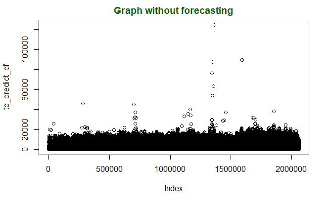

```r
plot(to_predict_df, main = "Graph without forecasting",
col.main = "darkgreen")
```

Utilizamos la funcion para predeci

```r
fit <- auto.arima(to_predict_df)
```

```r
forecastedValues <- forecast(fit, 30)
```

```r
print(forecastedValues)
```

|  | Point Forecast | Lo 80 | Hi 80 | Lo 95 | Hi 95 |
| --- | --- | --- | --- | --- | --- |
| 2061759 | 588.3646 | -1006.8773 | 2183.607 | -1851.347 | 3028.077 |
| 2061760 | 616.9491 | -979.7310 | 2213.629 | -1824.962 | 3058.861 |
| 2061761 | 858.4964 | -739.0958 | 2456.089 | -1584.810 | 3301.803 |
| 2061762 | 354.0844 | -1244.0291 | 1952.198 | -2090.019 | 2798.188 |
| 2061763 | 425.1996 | -1178.5447 | 2028.944 | -2027.516 | 2877.915 |
| 2061764 | 787.5645 | -845.5589 | 2420.688 | -1710.082 | 3285.211 |
| 2061765 | 522.8204 | -1115.8078 | 2161.449 | -1983.245 | 3028.886 |
| 2061766 | 496.2896 | -1142.4587 | 2135.038 | -2009.960 | 3002.539 |
| 2061767 | 622.4469 | -1026.4909 | 2271.385 | -1899.386 | 3144.280 |
| 2061768 | 552.4656 | -1096.5076 | 2201.439 | -1969.421 | 3074.353 |

[output cut: 20 more lines]

```r
df_arima <- data.frame(forecastedValues[4])
df_arima
```

| mean |
| --- |
| 588.3646 |
| 616.9491 |
| 858.4964 |
| 354.0844 |
| 425.1996 |
| 787.5645 |
| 522.8204 |
| 496.2896 |
| 622.4469 |
| 552.4656 |

[output cut: 20 more lines]

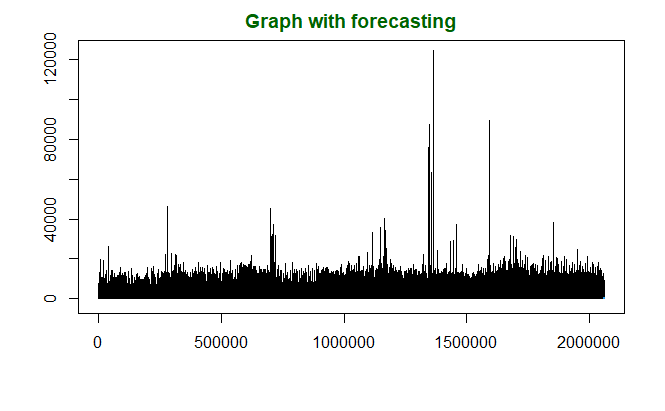

```r
plot(forecastedValues, main = "Graph with forecasting",
col.main = "darkgreen")
```